# Features

Closeread enables scrollytelling

Draw your readers attention with:

The first step is load the library, enabling access to its full set of features for the tasks ahead.

The next step is loading a data frame with economic data, enabling us to explore patterns and relationships across various financial indicators.

We generate a plot to visualize the data, using dates on the x-axis and corresponding value on the y-axis. This allows us to observe trends over time, identify patterns, and hightlight any significant fluctuations or anomalies in the dataset.

By splitting the chart based on variable type, we can highlight how different kinds of data behave and interact within the dataset.

Now, how to explain this chart?

PCE(Personal Consumption Expenditures) represents the total value of goods and services consumed by individuals. It is a key indicator of consumer spending and is used to assess economic activity and inflation trends.

POP(Population of the United States) refers to the total number of people residing in the U.S. This variable is essential for per capital calculations and demographic analysis.

PSAVERT(Personal Saving Rate) Indicates the percentage of disposable income that individuals save rather than spend. It reflects consumer financial behavior and economic confidence.

UEMPMED(Median Duration of Unemployment) Measures the median number of weeks individuals remain unemployed. It helps assess the health of the labor market and the effectiveness of job placement effors.

How neural nets works

What is bond yiels

1. Highlighting
2. Zooming
3. Panning

```python
import numpy as np
import pandas as pd
import plotnine

from plotnine import *
from plotnine.data import economics_long

(
ggplot(economics_long, aes(x = "date", y = "value"))
+ geom_line()
+ facet_wrap("variable", scales='free_y')
+ theme_bw()
)
```

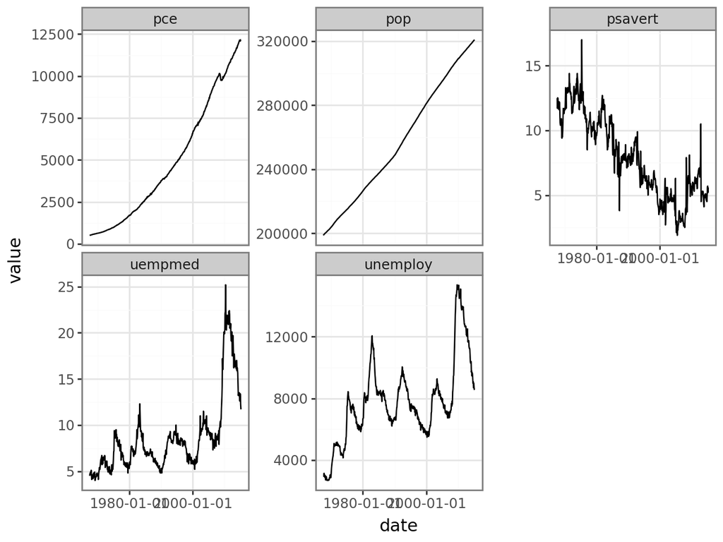

[video not shown]